# Data Exploration

Rachel Ledig

11/9/2020

Housekeeping

```r
load(file=paste0(iFol,"data.RData"))
```

Data Exploration

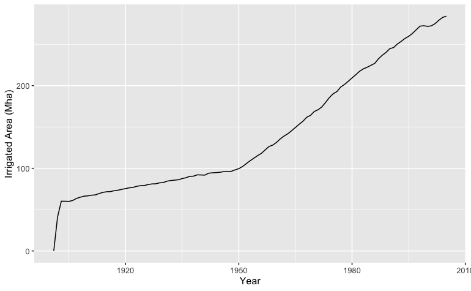

```r
globalIrrigArea <- as.data.frame(globalIrrigArea)
globalIrrigArea$year <- c(1901:2005)
ggplot(globalIrrigArea) + geom_line(aes(year, globalIrrigArea, group = 1)) + xlab("Year") + ylab("Irrigated Area (Mha)")
```

This graph freaks me out.. things look too linear. Is this reminant of the fact that all of this is coming from LPJmL?

Let me create one large data set with all variables for each cell.

```r
irrFracdf <- as.data.frame(irrFrac)
irrFracdf$lat <- lat #adding spacial coords
irrFracdf$lon <- lon
irrFracdf <- irrFracdf[, c(106, 107, 1:105)]#flipping the order
names(irrFracdf)[3:107] <- c("1901":"2005")
names(irrFracdf)[1] <- "lat"
names(irrFracdf)[2] <- "lon"
irrfrac_long <- gather(irrFracdf, year, measurement, "1901":"2005", factor_key=TRUE)
colnames(irrfrac_long)[4] <- "Frac"
head(irrfrac_long, 20)
```

|  | lat | lon | year | Frac |
| --- | --- | --- | --- | --- |
| 1 | -16.25 | -179.75 | 1901 | 0 |
| 2 | 65.25 | -179.75 | 1901 | 0 |
| 3 | 65.75 | -179.75 | 1901 | 0 |
| 4 | 66.25 | -179.75 | 1901 | 0 |
| 5 | 66.75 | -179.75 | 1901 | 0 |
| 6 | 67.25 | -179.75 | 1901 | 0 |
| 7 | 67.75 | -179.75 | 1901 | 0 |
| 8 | 68.25 | -179.75 | 1901 | 0 |
| 9 | 68.75 | -179.75 | 1901 | 0 |
| 10 | 70.75 | -179.75 | 1901 | 0 |

[output cut: 10 more lines]

```r
NA
NA
```

Lets put all the other data in long format as well.

```r
d <- irrfrac_long
rm(irrfrac_long, irrFrac, irrFracdf)

#correct calculation of cell area
cellarea <- (111194.9/2)*(111194.9/2)*cos(lat/180*pi) # cellarea in m2

#Adding cell area, still m2
cellareadf <- as.data.frame(cellarea)
#repeating the cell area for all 105 years
cellarealong <- cellareadf[rep(seq_len(nrow(cellareadf)), 105), ]
d$cellaream2 <- cellarealong
rm(cellarea, cellareadf, cellarealong)

#adding full country data
#repeating the full country data for all 105 years
fullCountryDatalong <- fullCountryData[rep(seq_len(nrow(fullCountryData)), 105), ]
d$COW <- fullCountryDatalong$COW
d$REG <- fullCountryDatalong$REG
d$countryname <- fullCountryDatalong$Countryname
d$ISO <- fullCountryDatalong$ISO
rm(fullCountryData, fullCountryDatalong)

#lets add the regions of all of these countries
regions <- read.csv(file.choose())
```

```
Error in file.choose() : file choice cancelled
```

Let me do some summary statistics. Aha! This will come back in handy!

```r
#setting the quantiles
# p <- c(0.025, 0.5, 0.975)
# p_names <- map_chr(p, ~paste0(.x*100, "%"))
# p_funs <- map(p, ~partial(quantile, probs = .x, na.rm = TRUE)) %>% set_names(nm = p_names)
# p_funs
#
#
# quants <-
#   d %>%
#   group_by(countryname, year) %>%
#   summarize_at(vars(Frac, GDP, distnextirr, cellaream2, popdens, medianincrease, precipmm),
#                funs(!!!p_funs))

#reorder so this is more readable
#this is annoying, how to fix this...
#quants <- quants[, c(1,2,3,9,15,4,10,16,5,11,17,6,12,18,7,13,19,8,14,20)]
```

Ok this is annoying… can I plot it instead?

```r
setwd("/Volumes/RachelExternal/Thesis/Thesis/Plots")

countries = unique(d$countryname)
country_plots = list()

#ok for precipitation. Lets check out the quantiles and ranges
for(country_ in countries) {
  country_plots[[country_]] = ggplot(d %>% filter(countryname == country_), aes(x=year, y=`precipmm`)) +
    geom_boxplot() +
    theme(axis.text.x = element_text(angle = 90)) +
    ggtitle(country_) +
    ylab("Grid Cell Percip (mm/year)") +
    xlab("Year") +
    theme(plot.title = element_text(size = 32, face = "bold", hjust=0.5), axis.title.x = element_text(size = 18, face = "bold"), axis.title.y = element_text(size = 18, face = "bold"))
  ggsave(country_plots[[country_]], file=paste0("PrecipVar_", country_,".png"), width = 44.45, height = 27.78, units = "cm", dpi=300)
}
```

```r
#mean yield increase
for(country_ in countries) {
  country_plots[[country_]] = ggplot(d %>% filter(countryname == country_), aes(x=year, y=`meanincrease`)) +
    geom_boxplot() +
    theme(axis.text.x = element_text(angle = 90)) +
    ggtitle(country_) +
    ylab("Mean Yield Increase") +
    xlab("Year") +
    theme(plot.title = element_text(size = 32, face = "bold", hjust=0.5), axis.title.x = element_text(size = 18, face = "bold"), axis.title.y = element_text(size = 18, face = "bold"))
  ggsave(country_plots[[country_]], file=paste0("Meanincrease", country_,".png"), width = 44.45, height = 27.78, units = "cm", dpi=300)
}
```

```r
#this is for population density
for(country_ in countries) {
  country_plots[[country_]] = ggplot(d %>% filter(countryname == country_), aes(x=year, y=`popdens`)) +
    geom_boxplot() +
    theme(axis.text.x = element_text(angle = 90)) +
    ggtitle(country_) +
    ylab("Grid Cell Population Density (people/km2)") +
    xlab("Year") +
    theme(plot.title = element_text(size = 32, face = "bold", hjust=0.5), axis.title.x = element_text(size = 18, face = "bold"), axis.title.y = element_text(size = 18, face = "bold"))
  ggsave(country_plots[[country_]], file=paste0("CellPopdens", country_,".png"), width = 44.45, height = 27.78, units = "cm", dpi=300)
}
```

```r
#dealing with cftfrac totals

#here I've summed all crop fractions per cell, both rainfed and irrigated
d$cftfracsum <- rowSums(d[ , c(16:47)], na.rm=TRUE)
max(d$cftfracsum) #theoretically this should be 1...
quantile(d$cftfracsum, probs = c(0, 0.025, 0.5, 0.975, 1 ))

for(country_ in countries) {
  country_plots[[country_]] = ggplot(d %>% filter(countryname == country_), aes(x=year, y=`cftfracsum`)) +
    geom_boxplot() +
    theme(axis.text.x = element_text(angle = 90)) +
    ggtitle(country_) +
    ylab("Grid Cell Total Crop Fraction") +
    xlab("Year") +
    theme(plot.title = element_text(size = 32, face = "bold", hjust=0.5), axis.title.x = element_text(size = 18, face = "bold"), axis.title.y = element_text(size = 18, face = "bold"))
  ggsave(country_plots[[country_]], file=paste0("Total Crop Fraction", country_,".png"), width = 44.45, height = 27.78, units = "cm", dpi=300)
}
```

Lets break down cft frac a bit more and check it numbers match.

```r
#lets check out just RAINFED totals
d$cftrf <- rowSums(d[ , c(16:31)], na.rm=TRUE)
max(d$cftrf) #Again slightly high, but makes sense that the value in some cells would be near 1.
mean(d$cftrf)
quantile(d$cftrf, probs = c(0, 0.025, 0.5, 0.975, 1 ))



#lets check out just IRRIGATED totals and see if they match "Frac"
d$cftirr <- rowSums(d[ , c(32:47)], na.rm=TRUE)
max(d$cftirr) #Again slightly high
mean(d$cftirr)
quantile(d$cftirr, probs = c(0, 0.025, 0.5, 0.975, 1 ))

all(d$Frac == d$cftirr) #sick, they are the same
```

[output not shown]

Can i change these plots so that i have a stacked bar chart for each country for each year? Gonna need to do a bit more data wrangling here to make this make sense.

```r
for(country_ in countries) {
  country_plots[[country_]] = d %>%
  subset(countryname == country_, select = c(3, 8, 16:47)) %>%
  gather("croptype", "fraction", 3:34) %>%
  group_by(year, croptype) %>%
  summarize_at(vars(fraction),
               funs(!!!p_funs, mean)) %>%
  ggplot(aes(x= year, y= `50%`, group = croptype)) +
  geom_line(aes(y = `5%`), colour = "grey50", linetype = "dotted") +
  geom_line(aes(y = `95%`), colour = "grey50", linetype = "dotted") +
  geom_line(aes(y = mean), colour = "red") +
  geom_line() +
  ggtitle(country_) +
  scale_x_discrete(breaks=seq(1901,2005,10)) +
  facet_wrap(~croptype, scale = "free_y", ncol = 4)
 ggsave(country_plots[[country_]], file=paste0("CftFrac", country_,".png"), width = 44.45, height = 70, units = "cm", dpi=300)
}
```

Ok, let’s leave this as it is for now. I will add more data as I go along. What are some ideas to explore this data. Maybe? - Irrigated Area vs. Country – Irrigated area vs Crop Type – Irrigated Area vs. Temp or humidity – Irrigated area vs. GDP

Lets do irrigated area per country. steps 1. group by countries 2. calculate irrgated area $(sum(irrfrac(i) * cell area(i))/sum(cell area(country))$ 3. do this for all years 4. plot in line graph for major countries

```r
#total irrigated fraction per country per year
#no need to divide for km2 conversion, as final is unitless
irrfractots <- d %>% group_by(countryname, year) %>% summarise(fractot = ((sum(Frac*cellaream2))/sum(cellaream2))*100)

#just checking that I did the above operation correct
d %>% group_by(ISO, year) %>% mutate(c = sum(cellaream2)) %>% summarise(c)
d %>% group_by(ISO, year) %>% mutate(f = sum(Frac*cellaream2)) %>% summarise(f)


#irrfracggp <- ggplot(irrfractots, aes(x=year,y=fractot, group = countryname, color = countryname)) + geom_line() + geom_point()
#irrfracggp <- irrfracggp + theme(legend.title = element_blank()) +
  #xlab("Year") +
  #ylab("% of Irrigated Area") +
  #ggtitle("Fraction of area irrigated by country per year")
```

```r
pirrfrac <- plot_ly(irrfractots, x = ~year, y = ~fractot, color = ~countryname, type = 'scatter', mode = 'lines')
pirrfrac <- pirrfrac %>% layout(autosize = F, height = 500)
pirrfrac <- pirrfrac %>% layout(title = 'Total Irrigation Fraction per Country',
         xaxis = list(title = 'Year'),
         yaxis = list(title = '% Irrigated Land of Total Area'))
hide_legend(pirrfrac)
```

So total GDP per country is calculated by: $sum(lpjGDP(GDP/capita) * population density(capita/km^2) * Cell Area(m^2)*0.000001) = GDP$

So total GDP per capita is calculated by: $sum(lpjGDP(GDP/capita) * population density(capita/km^2) * Cell Area(m^2)*0.000001)/sum(sum(Population Density(capita/m^2)*cell area(m^2)*0.000001)) = GDP$

GDP has a particular feature. It is the same for all cells of a particular country. So it cannot be summed in the way that population density can be.

```r
#converted to km2
GDPtot <- d %>% drop_na() %>% group_by(countryname, year) %>% summarise(gdptotal = GDP*sum(popdens*cellaream2*0.000001)) %>% unique()

GDPcap <- d %>% drop_na() %>% group_by(countryname, year) %>% summarise(gdpcap = (sum(GDP*popdens*cellaream2*0.000001))/sum(popdens*cellaream2*0.000001))

#My attempt at a simple ggplot. Plotly worked better here.
#GDPggp <- ggplot(GDPtot, aes(x=year,y=gdptotal, group = countryname)) + geom_line() + geom_point()
#GDPggp <- GDPggp + theme(legend.title = element_blank()) +
  #xlab("Years") +
  #ylab("GDP (2011 USD)") +
  #ggtitle("GDP per Country Per year")
```

```r
pGDPtot <- plot_ly(GDPtot, x = ~year, y = ~gdptotal, color = ~countryname, type = 'scatter', mode = 'lines')
pGDPtot <- pGDPtot %>% layout(autosize = F, height = 500) %>% layout(title = 'GDP per Country',
         xaxis = list(title = 'Year'),
         yaxis = list(title = 'GDP (2011 USD)'))
hide_legend(pGDPtot)

pGDPcap <- plot_ly(GDPcap, x = ~year, y = ~gdpcap, color = ~countryname, type = 'scatter', mode = 'lines')
pGDPcap <- pGDPcap %>% layout(autosize = F, height = 500) %>% layout(title = 'Total GDP per Capita per Country',
         xaxis = list(title = 'Year'),
         yaxis = list(title = 'GDP/cap (2011 USD)'))
hide_legend(pGDPcap)
```

And another, population by country? $sum(Population Density(capita/km^2)*cell area(m^2)*0.000001)$ I wanna check out overall population density? So, I’ll divide it by total area? $sum(Population Density(capita/km^2)*cell area(m^2)*0.000001)/sum(cell area (m^2)*0.000001)$

```r
POPtot <- d %>% group_by(countryname, year) %>% summarise(poptotal = (sum(popdens*(cellaream2*0.000001))))

POPdenstot <- d %>% group_by(countryname, year) %>% summarise(popdenstotal = (sum(popdens*cellaream2*0.000001))/sum(cellaream2*0.000001))

head(POPtot)
head(POPdenstot)

#POPggp <- ggplot(POPtot, aes(x=year,y=poptotal, group = ISO)) + geom_line() + geom_point()
#POPggp <- POPggp + theme(legend.title = element_blank()) +
  #xlab("Year") +
  #ylab("Population") +
  #ggtitle("Population per Country per Year")


#POPDENSggp <- ggplot(POPdenstot, aes(x=year,y=popdenstotal, group = ISO)) + geom_line() + geom_point()
#POPDENSggp <- POPDENSggp + theme(legend.title = element_blank()) +
  #xlab("Year") +
  #ylab("Overall Population Density (capita/m^2") +
  #ggtitle("Overall Population Density per Year per Country")
```

```r
pPOP <- plot_ly(POPtot, x = ~year, y = ~poptotal, color = ~countryname, type = 'scatter', mode = 'lines')
pPOP <- pPOP %>% layout(autosize = F, height = 500) %>% layout(title = 'Population per Country',
         xaxis = list(title = 'Year'),
         yaxis = list(title = 'Population'))
hide_legend(pPOP)
```

```r
#idk if this is helpful
pPOPdens <- plot_ly(POPdenstot, x = ~year, y = ~popdenstotal, color = ~countryname, type = 'scatter', mode = 'lines')
pPOPdens <- pPOPdens %>% layout(autosize = F, height = 500) %>% layout(title = 'Overall Population Density per Country',
         xaxis = list(title = 'Year'),
         yaxis = list(title = 'Population Density (capita/m^2)'))
hide_legend(pPOPdens)
```

```r
PrecipTot <- d %>% group_by(countryname, year) %>% summarise(PrecipTot = (sum(popdens*(cellaream2*0.000001))))
```